# Voto estratégico 1+1+1 al Senado en 2019

Pablo Cabrera-Álvarez

julio de 2019

## Marcar 1+1+1

En las elecciones del pasado abril el Senado jugó un papel más destacado que en pasadas citas electorales. En parte, porque en la pasada legislatura la cámara alta tuvo un papel destacado con la aplicación del 155 en Cataluña y, en parte, porque la mayoría conservadora del Senado estaba en peligro ante la fragmentación del voto de la derecha.

Ante el escenario de fragmentación en la derecha, para frenar una mayoría progresista en la cámara alta solo cabían dos posibilidades: ejercer el voto útil (hacia el PP) o un voto estratégico del tipo 1 (PP) + 1 (C’s) + 1 (VOX). Esta segunda estrategia protagonizó un mensaje de whatsapp que se hizo [viral durante la campaña](https://verne.elpais.com/verne/2019/04/17/articulo/1555498988_742073.html): 1 (PP) + 1 (C’s) + 1 (VOX). Sin embargo, el éxito de esta estrategia necesitaba un alto grado de coordinación entre los votantes o los partidos proponiendo una coalición en la candidatura al Senado, como ya hicieran el PSOE e IU en las elecciones de 2000. Los resultados electorales demuestran que ninguna de estas estrategias, el 1+1+1 o el voto útil, sirvieron para evitar una mayoría progresista en el Senado, aunque cabe preguntarse por el impacto que llegó a tener un mensaje anónimo viral sobre el comportamiento de los electores.

En las elecciones al Senado, durante los años del bipartidismo, los casos de voto dual - diferente al congreso y al Senado - o voto estratégico fueron prácticamente nulos. Los electores solían marcar votar al mismo partido al Congreso y al Senado, y en la papeleta del Senado, a pesar de ser listas abiertas, marcaban a los tres candidatos del mismo partido. Así, el partido más votado en cada circunscripción (peninsular) consegía tres senadores mientras que el segundo partido quedaba con un asiento.

Para investigar el efecto del voto estratégico en estas elecciones utilizo dos fuentes de datos: los resultados electorales y el [estudio postelectoral del CIS](http://datos.cis.es/pdf/Es3248rei_A.pdf).

## Resultados electorales

Los datos electorales agregados, en este caso a nivel de circunscripción, aportan alguna pista sobre el impacto del voto estratégico (1+1+1) en estas últimas elecciones. Partimos de la hipótesis de que es improbable que haya voto estratégico o útil si los porcentajes de voto al Senado y al Congreso coinciden. Por un lado, habrá voto útil si el principal partido de la derecha, el PP, obtiene más votos en los tres candidatos al Senado que al Congreso. Por otro lado, habrá voto estratégico 1+1+1 si los tres cabezas de lista al Senado de PP, C’s y VOX obtienen más votos que los que obtienen las candidaturas de cada uno de estos partidos en la urna correspondiente al Congreso.

El primer conjunto de mapas muestra, para las últimas tres elecciones generales, la diferencia entre el porcentaje de votos obtenidos por el candidato más votado al Senado y la candidatura al congreso. El segundo conjunto de mapas presenta la misma diferencia pero utilizando el candidato al Senado que menos votos obtuvo.

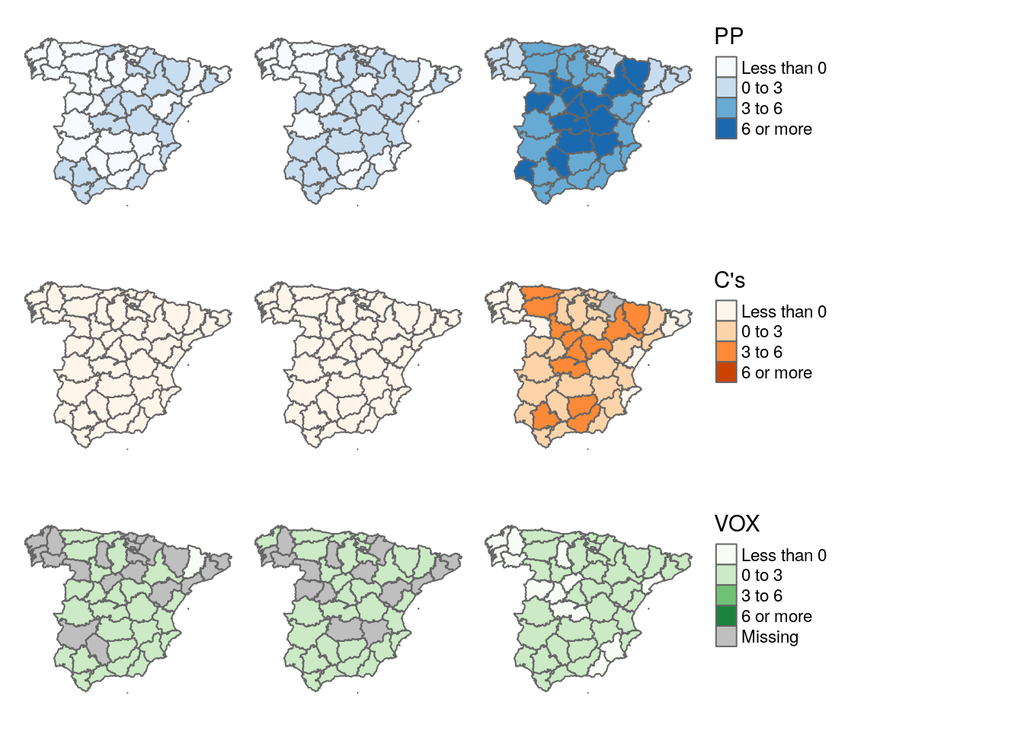

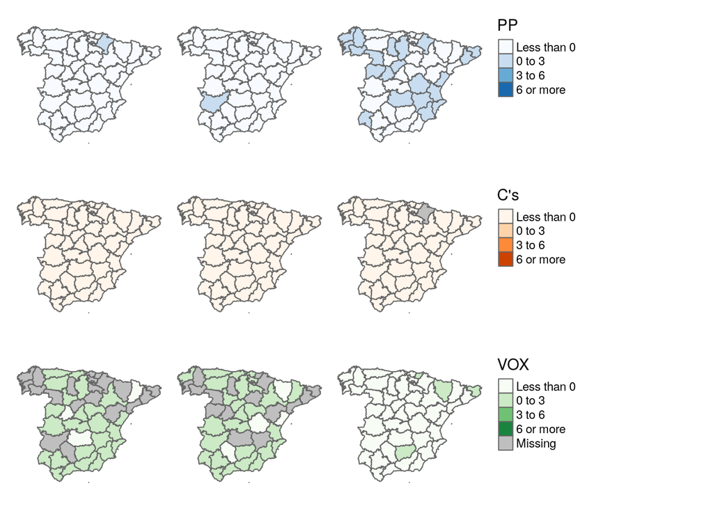

## Los datos del CIS

[figure not shown]